# Регрессионный анализ, часть 1

## Математические методы в зоологии - на R, осень 2013

Марина Варфоломеева  
Каф. Зоологии беспозвоночных, СПбГУ

# Знакомимся с линейными моделями

- Модель простой линейной регрессии
- Проверка валидности модели
- Оценка качества подгонки модели

# Вы сможете

- подобрать модель линейной регрессии и записать ее в виде уравнения
- проверить валидность модели при помощи t- или F-теста
- оценить долю изменчивости, которую объясняет модель, при помощи $R^2$

# Модель простой линейной регрессии

# Линейная регрессия

- простая

$$Y _i = β _0 + βx _i + \epsilon _i$$

- множественная

$$Y _i = β _0 + βx _{1 i} + + βx _{2 i} + ... + \epsilon _i$$

# Запись моделей в R

```r
зависимая_переменная ~ модель
```

$\hat y _i = b _0 + bx _i$ (простая линейная регрессия со свободным членом (intercept))

- Y ~ X
- Y ~ 1 + X
- Y ~ X + 1

$\hat y _i = bx _i$ (простая линейная регрессия без свободного члена)

- Y ~ X - 1
- Y ~ -1 + X

$\hat y _i = b _0$ (уменьшенная модель, линейная регрессия y от свободного члена)

- Y ~ 1
- Y ~ 1 - X

# Минимизируем остаточную изменчивость

$Y _i = β _0 + βx _i + \epsilon _i$ - модель регрессии

$\hat y _i = b _0 + b _1 x _i$ - оценка модели

нужно оценить $\beta _0$, $\beta _1$ и $σ^2$

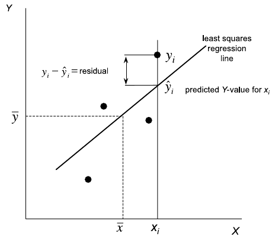

- Метод наименьших квадратов (Ordinary Least Squares, см. рис.)

Еще есть методы максимального правдоподобия (Maximum Likelihood, REstricted Maximum Likelihood)

Рисунок из кн. Quinn, Keough, 2002, стр. 85, рис. 5.6 a

# Оценки параметров линейной регрессии

минимизируют $\sum{(y _i - \hat y _i)^2}$, т.е. остатки.

| Параметры | Оценки параметров | Стандартные ошибки оценок |
| --- | --- | --- |
| $\beta _1$ | $$b _1 = \frac {\sum _{i=1}^{n} {[(x _i - \bar x)(y _i - \bar y)]}}{\sum _{i=1}^{n} {(x _i - \bar x)^2}}$$ | $$SE _{b _1} = \sqrt{\frac{MS _e}{\sum _{i=1}^{n} {(x _i - \bar x)^2}}}$$ |
| $\beta _0$ | $$b _0 = \bar y - b _1 \bar x$$ | $$SE _{b _0} = \sqrt{MS _e [\frac{1}{n} + \frac{\bar x}{\sum _{i=1}^{n} {(x _i - \bar x)^2}}]}$$ |
| $\epsilon _i$ | $$e _i = y _i - \hat y _i$$ | $$\approx \sqrt{MS _e}$$ |

- Стандартные ошибки коэффициентов нужны
  - для построения доверительных интервалов
  - для статистических тестов

Таблица из кн. Quinn, Keough, 2002, стр. 86, табл. 5.2

# Коэффициенты регрессии

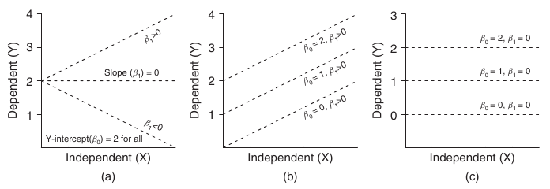

Рисунок из кн. Logan, 2010, стр. 170, рис. 8.2

- Если нужно сравнивать - лучше стандартизованные (= "бета коэффициенты") коэффициенты (на след.лекции про сравнение моделей)
  - $b^\ast _1 = {b _1 {\sigma _x} \over {\sigma _y}}$
  - не зависят от масштаба

# Пример: усыхающие личинки мучных хрущаков

Как зависит потеря влаги личинками [малого мучного хрущака](http://ru.wikipedia.org/wiki/%D0%A5%D1%80%D1%83%D1%89%D0%B0%D0%BA_%D0%BC%D0%B0%D0%BB%D1%8B%D0%B9_%D0%BC%D1%83%D1%87%D0%BD%D0%BE%D0%B9) *Tribolium confusum* от влажности воздуха? (Nelson, 1964)

9 экспериментов, продолжительность 6 дней

- разная относительная влажность воздуха, % (`humidity`)
- измерена потеря влаги, мг (`weightloss`)

Данные в файлах `nelson.xlsx` и `nelson.csv`

[figure not shown]

Данные из Sokal, Rohlf, 1997, табл. 14.1 по Logan, 2010. глава 8, пример 8c

# Читаем данные из файла и знакомимся с ними

Внимание, установите рабочую директорию, или используйте полный путь к файлу

```r
setwd("C:\\mathmethr\week2")
## из .xlsx
library(XLConnect)
wb <- loadWorkbook(".\data\nelson.xlsx")
nelson <- readWorksheet(wb, sheet = 1)
## или из .csv
# nelson <- read.table(file=".\data\nelson.xlsx", header = TRUE, sep = "\t", dec = ".")
```

```r
str(nelson)
```

```
## 'data.frame':    9 obs. of  2 variables:
##  $ humidity  : num  0 12 29.5 43 53 62.5 75.5 85 93
##  $ weightloss: num  8.98 8.14 6.67 6.08 5.9 5.83 4.68 4.2 3.72
```

```r
head(nelson)
```

```
##   humidity weightloss
## 1      0.0       8.98
## 2     12.0       8.14
## 3     29.5       6.67
## 4     43.0       6.08
## 5     53.0       5.90
## 6     62.5       5.83
```

# Как зависит потеря веса от влажности? График рассеяния.

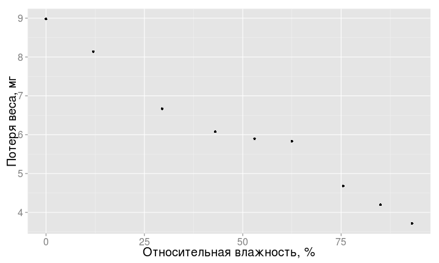

```r
library(ggplot2)
p_nelson <- ggplot(data=nelson, aes(x = humidity, y = weightloss)) +
  geom_point() +
  labs(x = "Относительная влажность, %", y = "Потеря веса, мг")
p_nelson
```

# Внешний вид графиков можно менять при помощи тем

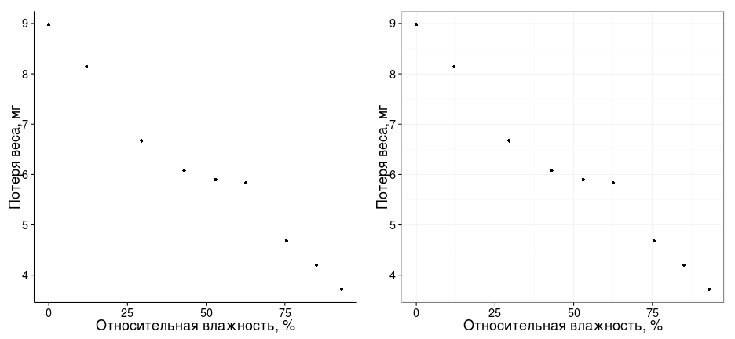

```r
p_nelson + theme_classic()
p_nelson + theme_bw()
theme_set(theme_classic()) # устанавливаем понравившуюся тему до конца сессии
```

# Подбираем параметры линейной модели

```r
nelson_lm <- lm(weightloss ~ humidity, nelson)
summary(nelson_lm)
```

```
##
## Call:
## lm(formula = weightloss ~ humidity, data = nelson)
##
## Residuals:
##     Min      1Q  Median      3Q     Max
## -0.4640 -0.0344  0.0167  0.0746  0.4524
##
## Coefficients:
##             Estimate Std. Error t value      Pr(>|t|)
## (Intercept)  8.70403    0.19156    45.4 0.00000000065 ***
## humidity    -0.05322    0.00326   -16.4 0.00000078161 ***
## ---
## Signif. codes:  0 '***' 0.001 '**' 0.01 '*' 0.05 '.' 0.1 ' ' 1
##
## Residual standard error: 0.297 on 7 degrees of freedom
## Multiple R-squared:  0.974,  Adjusted R-squared:  0.971
## F-statistic:  267 on 1 and 7 DF,  p-value: 0.000000782
```

# Добавим линию регрессии на график

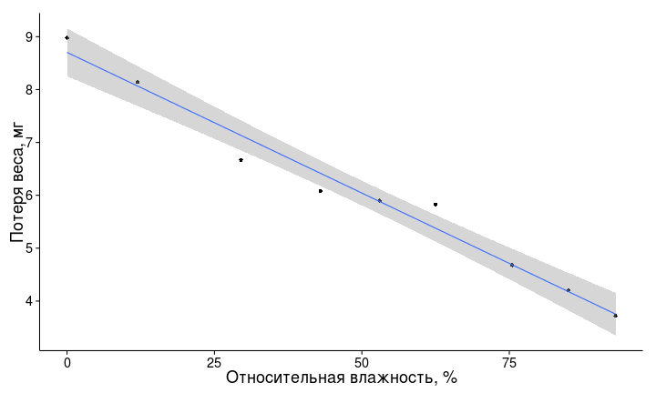

```r
p_nelson + geom_smooth(method = "lm")
```

# Неопределенность оценок коэффициентов и предсказанных значений

# Неопределенность оценок коэффициентов

- **Доверительный интервал коэффициента**
  - зона, в которой с $(1 - \alpha) \cdot 100\%$ вероятностью содержится среднее значение коэффициента
  - $b _1 \pm t _{\alpha, df = n - 2}SE _{b _1}$
  - $\alpha = 0.05$ => $(1 - 0.05) \cdot 100\% = 95\%$ интервал
- **Доверительная зона регрессии**
  - зона, в которой с $(1 - \alpha) \cdot 100$% вероятностью лежит регрессионная прямая

# Находим доверительные интервалы коэффициентов

```r
# Вспомните, в выдаче summary(nelson_lm) были только оценки коэффициентов
# и стандартные ошибки

# оценки коэффициентов отдельно
coef(nelson_lm)
```

```
## (Intercept)    humidity
##      8.7040     -0.0532
```

```r
# доверительные интервалы коэффициентов
confint(nelson_lm)
```

```
##               2.5 %  97.5 %
## (Intercept)  8.2510  9.1570
## humidity    -0.0609 -0.0455
```

# Оценим, какова средняя потеря веса при заданной влажности

**Нельзя давать оценки вне интервала значений $X$!**

```r
# новые данные для предсказания значений
newdata <- data.frame(humidity = c(50, 100))
predict(nelson_lm, newdata,
        interval = "confidence", se = TRUE)
```

```
## $fit
##    fit  lwr  upr
## 1 6.04 5.81 6.28
## 2 3.38 2.93 3.83
##
## $se.fit
##      1      2
## 0.0989 0.1894
##
## $df
## [1] 7
##
## $residual.scale
## [1] 0.297
```

```r
# доверительный интервал к среднему значению
```

[figure not shown]

- При 50 и 100% относительной влажности ожидаемая средняя потеря веса жуков будет 6 $\pm$ 0.2 и 3.4 $\pm$ 0.4, соответственно.

# Строим доверительную зону регрессии

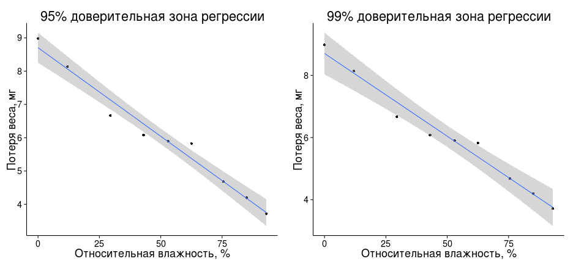

```r
p_nelson + geom_smooth(method = "lm") +
  ggtitle ("95% доверительная зона регрессии")
p_nelson + geom_smooth(method = "lm", level = 0.99) +
  ggtitle ("99% доверительная зона регрессии")
```

# Неопределенность оценок предсказанных значений

- **Доверительный интервал к предсказанному значению**
  - зона в которую попадают $(1 - \alpha) \cdot 100$% значений $\hat y _i$ при данном $x _i$
  - $\hat y _i \pm t _{0.05, n - 2}SE _{\hat y _i}$
  - $SE _{\hat y} = \sqrt{MS _{e} [1 + \frac{1}{n} + \frac{(x _{prediction} - \bar x)^2} {\sum _{i=1}^{n} {(x _{i} - \bar x)^2}}]}$
- **Доверительная область значений регрессии**
  - зона, в которую попадает $(1 - \alpha) \cdot 100$% всех предсказанных значений

# Предсказываем для новых значений

**Нельзя использовать для предсказаний вне интервала значений $X$!**

```r
# новые данные для предсказания значений
newdata <- data.frame(humidity = c(50, 100))
predict(nelson_lm, newdata,
        interval = "prediction", se = TRUE)
```

```
## $fit
##    fit  lwr  upr
## 1 6.04 5.30 6.78
## 2 3.38 2.55 4.21
##
## $se.fit
##      1      2
## 0.0989 0.1894
##
## $df
## [1] 7
##
## $residual.scale
## [1] 0.297
```

```r
# зона, в которой будут лежать 95% всех значений
```

[figure not shown]

- У 95% жуков при 50 и 100% относительной влажности будет потеря веса будет в пределах 6 $\pm$ 0.7 и 3.4 $\pm$ 0.8, соответственно.

# Данные для доверительной области значений

```r
# предсказанные значения для исходных данных
predict(nelson_lm, interval = "prediction")
```

```
##    fit  lwr  upr
## 1 8.70 7.87 9.54
## 2 8.07 7.27 8.86
## 3 7.13 6.38 7.89
## 4 6.42 5.67 7.16
## 5 5.88 5.14 6.62
## 6 5.38 4.63 6.12
## 7 4.69 3.92 5.45
## 8 4.18 3.39 4.97
## 9 3.75 2.95 4.56
```

```r
# объединим с исходными данными в новом датафрейме - для графиков
nelson_with_pred <- data.frame(nelson, predict(nelson_lm, interval = "prediction"))
```

# Строим доверительную область значений и доверительный интервал

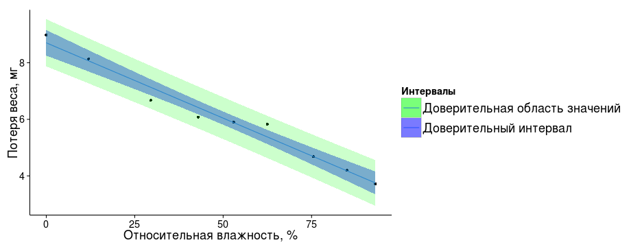

```r
p_nelson + geom_smooth(method = "lm", aes(fill = "Доверительный интервал"), alpha = 0.4) +
  geom_ribbon(data = nelson_with_pred,
              aes(y = fit, ymin = lwr, ymax = upr, fill = "Доверительная область значений"),
              alpha = 0.2) +
  scale_fill_manual('Интервалы', values = c('green', 'blue'))
```

# Проверка валидности модели

## $H _0: \beta _1 = 0$

## или t-, или F-тест

# Проверка при помощи t-критерия

$H _0 : b _1 = \theta$, $\theta = 0$ $$t = \frac{b _1 - \theta}{SE _{b _1}}$$ $df = n - 2$

# Проверка коэффициентов с помощью t-критерия есть в сводке модели

```r
summary(nelson_lm)
```

```
##
## Call:
## lm(formula = weightloss ~ humidity, data = nelson)
##
## Residuals:
##     Min      1Q  Median      3Q     Max
## -0.4640 -0.0344  0.0167  0.0746  0.4524
##
## Coefficients:
##             Estimate Std. Error t value      Pr(>|t|)
## (Intercept)  8.70403    0.19156    45.4 0.00000000065 ***
## humidity    -0.05322    0.00326   -16.4 0.00000078161 ***
## ---
## Signif. codes:  0 '***' 0.001 '**' 0.01 '*' 0.05 '.' 0.1 ' ' 1
##
## Residual standard error: 0.297 on 7 degrees of freedom
## Multiple R-squared:  0.974,  Adjusted R-squared:  0.971
## F-statistic:  267 on 1 and 7 DF,  p-value: 0.000000782
```

- Увеличение относительной влажности привело к достоверному замедлению потери веса жуками ($b _1 = -0.053$, $t = - 16.35$, $p < 0.01$)

# Проверка при помощи F-критерия

$H _0: \beta _1 = 0$

- Та же самая нулевая гипотеза. Как так получается?

# Общая изменчивость - отклонения от общего среднего значения

## $SS _{total}$

[figure not shown]

Рисунок из кн. Logan, 2010, стр. 172, рис. 8.3 a

## $SS _{total} = SS _{regression} + SS _{error}$

[figure not shown]

Рисунок из кн. Logan, 2010, стр. 172, рис. 8.3 a-c

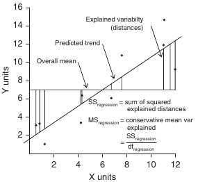

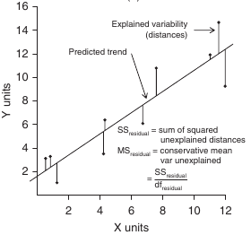

# Если зависимости нет, $b _1 = 0$

Тогда $\hat y _i = \bar y _i$  
и $MS _{regression} \approx MS _{error}$

[figure not shown]

Рисунок из кн. Logan, 2010, стр. 172, рис. 8.3 a-c

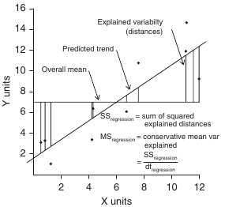

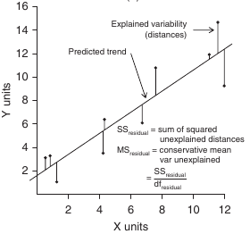

# F-критерий и распределение F-статистики

$$F = \frac {Объясненная\ изменчивость}{Необъясненная\ изменчивость} = \frac {MS _{regression}} {MS _{error}}$$

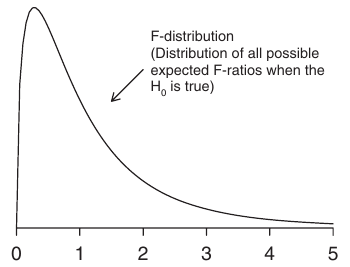

F-распределение при $H _0: b _1 = 0$

Зависит от

- $\alpha$
- $df _{regression}$
- $df _{error}$

Рисунок с изменениями из кн. Logan, 2010, стр. 172, рис. 8.3 d

# Таблица результатов дисперсионного анализа

| Источник изменчивости | Суммы квадратов отклонений, SS | Число степеней свободы, df | Средний квадрат отклонений, MS | F |
| --- | --- | --- | --- | --- |
| Регрессия | $$SS _r = \sum{(\bar y - \hat y _i)^2}$$ | $$df _r = 1$$ | $$MS _r = \frac{SS _r}{df _r}$$ | $$F _{df _r, df _e} = \frac{MS _r}{MS _e}$$ |
| Остаточная | $$SS _e = \sum{(y _i - \hat y _i)^2}$$ | $$df _e = n - 2$$ | $$MS _e = \frac{SS _e}{df _e}$$ |  |
| Общая | $$SS _t = \sum {(\bar y - y _i)^2}$$ | $$df _t = n - 1$$ |  |  |

- Минимальное упоминание в тексте - $F _{df _r, df _e}$, $p$

# Проверяем валидность модели при помощи F-критерия

```r
nelson_aov <- aov(nelson_lm)
summary(nelson_aov)
```

```
##             Df Sum Sq Mean Sq F value     Pr(>F)
## humidity     1  23.51   23.51     267 0.00000078 ***
## Residuals    7   0.62    0.09
## ---
## Signif. codes:  0 '***' 0.001 '**' 0.01 '*' 0.05 '.' 0.1 ' ' 1
```

- Количество влаги, потерянной жуками в период эксперимента, достоверно зависело от уровня относительной влажности ($F _{1, 7} = 267$, $p < 0.01$).

# Оценка качества подгонки модели

# Коэффициент детерминации

доля общей изменчивости, объясненная линейной связью x и y

$R^2 = \frac {SS _r} {SS _t}$

$0 \le R^2 \le 1$

Иначе рассчитывается как $R^2 = r^2$

# Коэффициент детерминации

можно найти в сводке модели

- Осторожно, не сравнивайте $R^2$ моделей с разным числом параметров, для этого есть $R^2 _{adjusted}$

```r
summary(nelson_lm)
```

```
##
## Call:
## lm(formula = weightloss ~ humidity, data = nelson)
##
## Residuals:
##     Min      1Q  Median      3Q     Max
## -0.4640 -0.0344  0.0167  0.0746  0.4524
##
## Coefficients:
##             Estimate Std. Error t value      Pr(>|t|)
## (Intercept)  8.70403    0.19156    45.4 0.00000000065 ***
## humidity    -0.05322    0.00326   -16.4 0.00000078161 ***
## ---
## Signif. codes:  0 '***' 0.001 '**' 0.01 '*' 0.05 '.' 0.1 ' ' 1
##
## Residual standard error: 0.297 on 7 degrees of freedom
## Multiple R-squared:  0.974,  Adjusted R-squared:  0.971
## F-statistic:  267 on 1 and 7 DF,  p-value: 0.000000782
```

# Take home messages

- Модель простой линейной регрессии $y _i = \beta _0 + \beta _1 \dot x _i + \epsilon _i$
- В оценке коэффициентов регрессии и предсказанных значений существует неопределенность. Доверительные интервалы можно расчитать, зная стандартные ошибки.
- Валидность модели линейной регрессии можно проверить при помощи t- или F-теста. $H _0: \beta _1 = 0$
- Качество подгонки модели можно оценить при помощи коэффициента детерминации $R^2$

# Дополнительные ресурсы

- Гланц, 1999, стр. 221-244
- Logan, 2010, pp. 170-207
- Quinn, Keough, 2002, pp. 78-110
- [Open Intro to Statistics](https://docs.google.com/viewer?docex=1&url=http://www.openintro.org/stat/down/OpenIntroStatSecond.pdf): [Chapter 7. Introduction to linear regression](https://docs.google.com/viewer?docex=1&url=http://www.openintro.org/stat/down/oiStat2_07.pdf), pp. 315-353.
- Sokal, Rohlf, 1995, pp. 451-491
- Zar, 1999, pp. 328-355